# Homwork 5

## 3.2.

FILE: hw5_model1.1.R

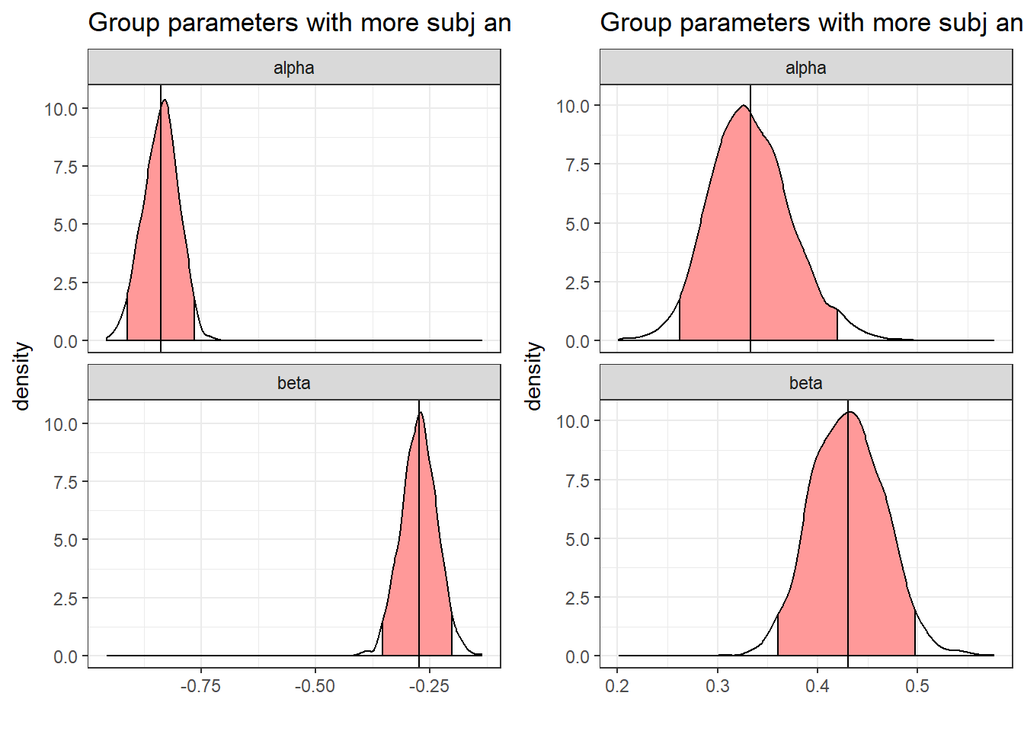

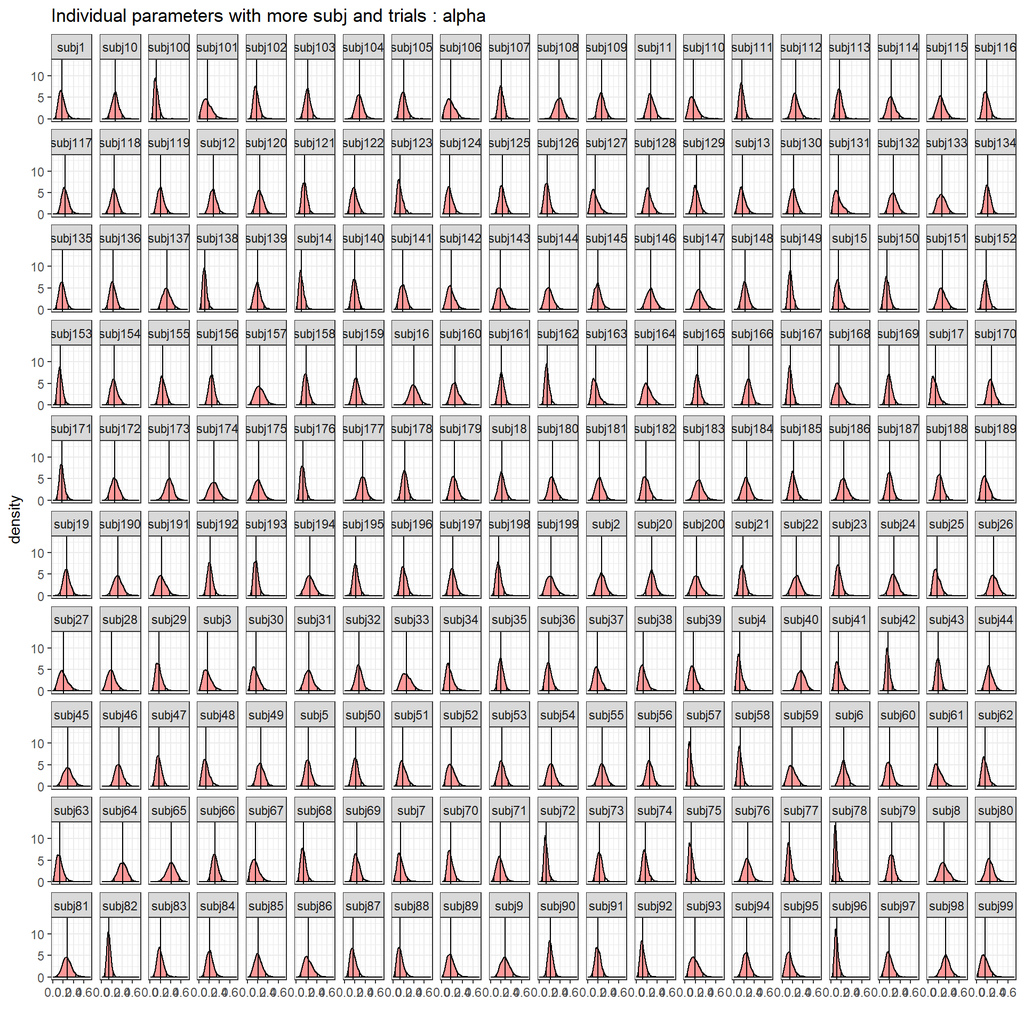

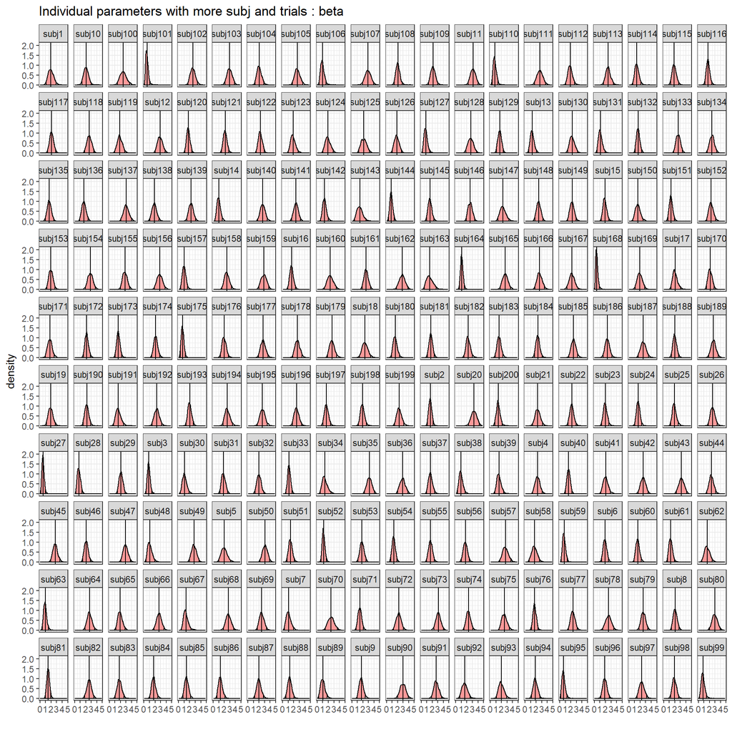

## 3.3.

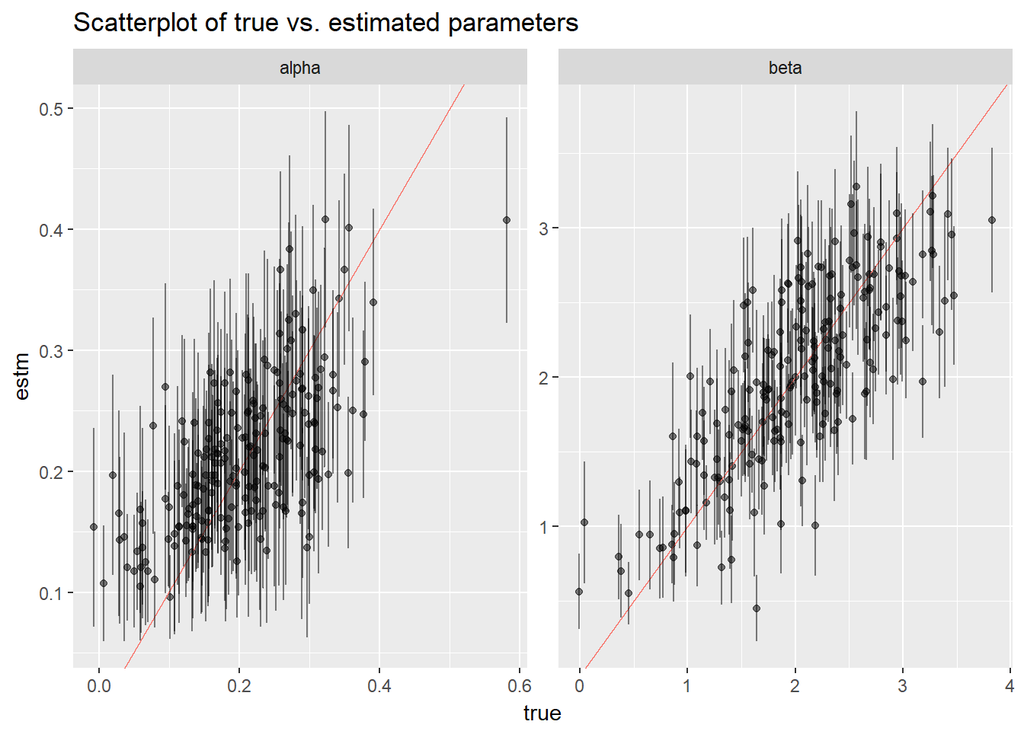

## 3.4. Do you notice “shrinkage” in one parameter but not so much in the other parameter? Can you explain why?

The shrinkage effect is more obvious in the alpha. The reason why is that the true values of the alpha are more extreme in their range than those of beta. Therefore, the shinkage effect plays more role in the alpha.

# Q4.Modify provided Stan and R codes so that we can allow two learning rates in the reinforcement learning model.

## 4.1. Find the posterior distribution of individual and group (hyper) parameters.

FILE: hw5_bonus.R, hw5_bonus.stan, simulate_hw5_bonus.R

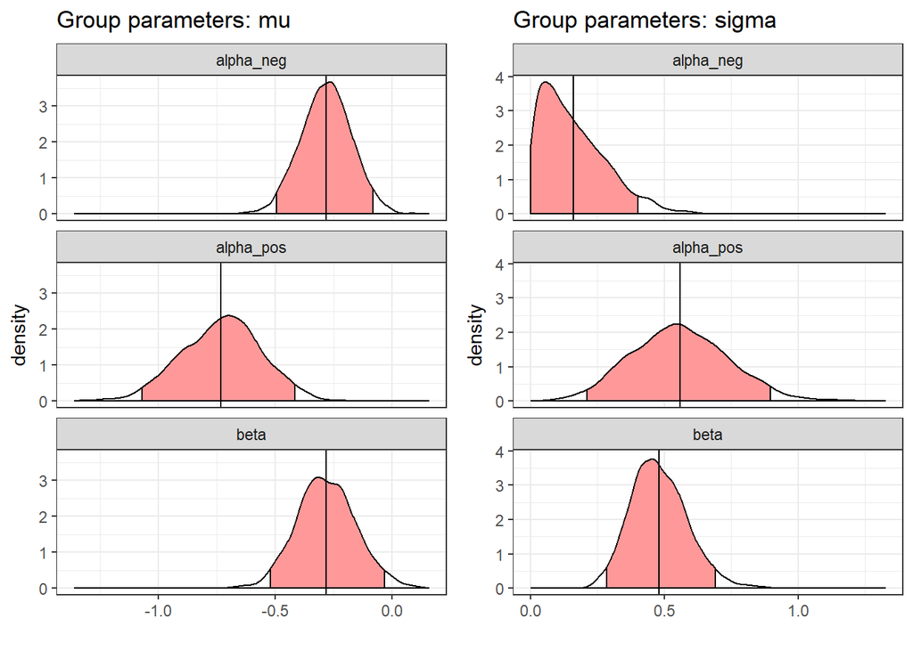

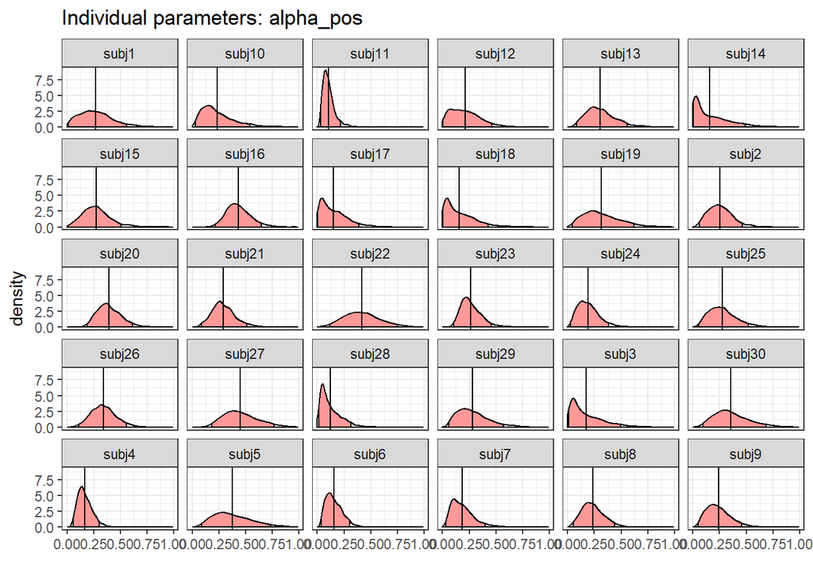

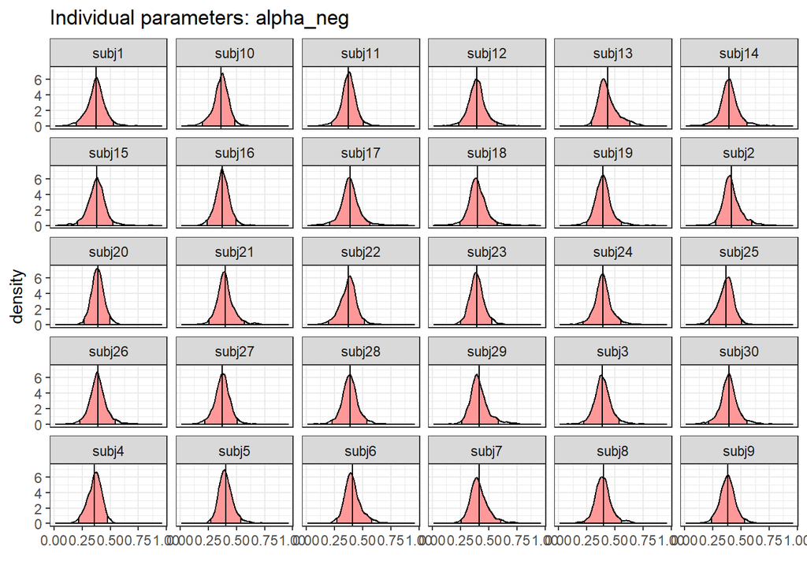

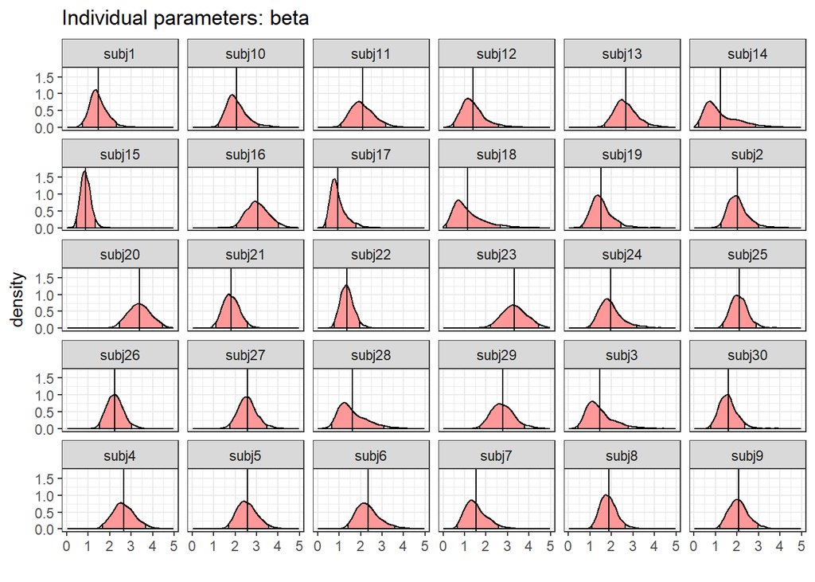